# Long Form EDA

Rebecca Siems

12/8/2020

# Introduction

For this project, I examine tweets about Donald Trump and Joe Biden up to three weeks before the 2020 Presidential election. Using bing and afinn sentiment analysis tools, I found assigned sentiments of words in the tweets. I explored the ways the average tweet sentiments changed up to the election, as well as their relationships to like and retweet counts. These analyses will also be used in my final Political Science Research Seminar paper, where I use the observations from this project to make predictions about the relationship between Twitter messaging and affective polarization, which is the us vs. them mentality of political polarization fueled by dislike of the other side. My goal for my analyses is to show the prevalence of negative and positive sentiments in tweets about the 2020 US presidential candidates as well as the level of engagement they receive.

Through my research in polarization literature, I’ve found that messaging tone in social media posts plays a major role in affective polarization, with incivility fueling affective polarization and civility promoting cooperation. I expect that more interactions with negative sentiments may lead to an increase in affective polarization among the American public, while positive interactions may lead to a decrease.

## Load Packages

```r
library(tidyverse)
library(tidytext)
library(textdata)
library(lubridate)
```

## Data Description

[US 2020 Election Tweets] (https://www.kaggle.com/manchunhui/us-election-2020-tweets)

The datasets include approximately 1.72 million tweets from October 15,2020 through November 8, 2020 that include Donald Trump’s and Joe Biden’s names. The tweets were collected using the Twitter API statuses_lookup and snsscrape. There are two datasets, one including tweets with Trump’s name and one including tweets with Biden’s name.

##### Read in Trump Dataset

```r
hashtag_donaldtrump <- read_csv("archive/hashtag_donaldtrump.csv")
View(hashtag_donaldtrump)
```

#### Read in Biden Dataset

```r
hashtag_joebiden <- read_csv("archive/hashtag_joebiden.csv")
View(hashtag_joebiden)
```

## Sentiment Lexicons

I will be using the sentiment lexicons bing and afinn for this project.

```r
get_sentiments("bing")
```

```
## # A tibble: 6,786 x 2
##    word        sentiment
##    <chr>       <chr>
##  1 2-faces     negative
##  2 abnormal    negative
##  3 abolish     negative
##  4 abominable  negative
##  5 abominably  negative
##  6 abominate   negative
##  7 abomination negative
##  8 abort       negative
##  9 aborted     negative
## 10 aborts      negative
## # ... with 6,776 more rows
```

Bing gives a tibble that has a column of words and another column assigning the words a negative or positive sentiment. Some of the negative words are “hypocritical,” “accuse,” and “god-awful.” Some examples of the positive words are “adore,” “glow,” and “ideal.”

```r
get_sentiments("afinn")
```

```
## # A tibble: 2,477 x 2
##    word       value
##    <chr>      <dbl>
##  1 abandon       -2
##  2 abandoned     -2
##  3 abandons      -2
##  4 abducted      -2
##  5 abduction     -2
##  6 abductions    -2
##  7 abhor         -3
##  8 abhorred      -3
##  9 abhorrent     -3
## 10 abhors        -3
## # ... with 2,467 more rows
```

#### Clean the main tibbles of Trump and Biden tweets

```r
# Selects the columns of interest
hashtag_donaldtrump <- hashtag_donaldtrump %>%
  select(created_at, tweet, likes, retweet_count, user_name, user_screen_name, user_description, user_followers_count, city, country, state_code) %>%
  # Remove tweets from users outside the US
  filter(country == "United States")

# Removes the whitespace and special characters from the tweets and puts them in a column of lists
trump_main <- hashtag_donaldtrump %>%
  mutate(
    trump_words = str_replace_all(tweet, "[^[A-Za-z,]]", " ") %>%
      str_squish(.) %>%
      str_replace_all(.,",",",") %>%
      str_split(boundary("word")),
    # Creates identification for each individual tweet to show which words are part of the same tweet and better contextualize the sentiments
    tweet_id = row_number()
  ) %>%
  # Unlists the words from the tweets and gives each word its own cell
  unnest(trump_words)

# Stores the bing sentiment tibble
bing_sent <- get_sentiments("bing")

# Joins the Trump tweet tibble with the bing sentiment tibble
trump_main <- trump_main %>%
  inner_join(bing_sent, by = c("trump_words" = "word"))
```

The Trump tweets tibble includes the date of the tweets’ creation, number of likes, number of retweets, user, and location of the tweets, filtered such that it only includes tweets from users in the United States. I also tidied the data to include a colum of the words from each tweet and a column of a number to identify the tweet that the words belong to. When joined with the bing lexicon, the join removes any word that bing doesn’t recognize, including any words with a neutral sentiment (e.g. “the,” “and,” “a,” etc.), misspellings, or any other words that aren’t included in the lexicon. There is also a column with the sentiments of each word.

# Bing data

```r
biden_main <- hashtag_joebiden %>%
  mutate(
    # Removes whitespace and punctuation
    biden_words = str_replace_all(tweet, "[^[A-Za-z,]]", " ") %>%
      str_squish(.) %>%
      str_replace_all(.,",",",") %>%
      str_split(boundary("word")),
    # Adds a tweet id so I can know which words are associated with each tweet
    tweet_id = row_number()
  ) %>%
  # Takes them out of the list
  unnest(biden_words)

biden_main <- biden_main %>%
  inner_join(bing_sent, by = c("biden_words" = "word"))
```

The Biden tibble follows the exact same process and has the same variables, but with tweets that are about Biden instead of Trump.

#### Count the sentiment words of the Trump and Biden tibbles

I counted the sentiment words to see overall which sentiment is more prevalent in the datasets and how big the difference is.

```r
# Counts the number of sentiment words
trump_main %>%
  count(sentiment)
```

```
## # A tibble: 2 x 2
##   sentiment     n
##   <chr>     <int>
## 1 negative  25231
## 2 positive  25433
```

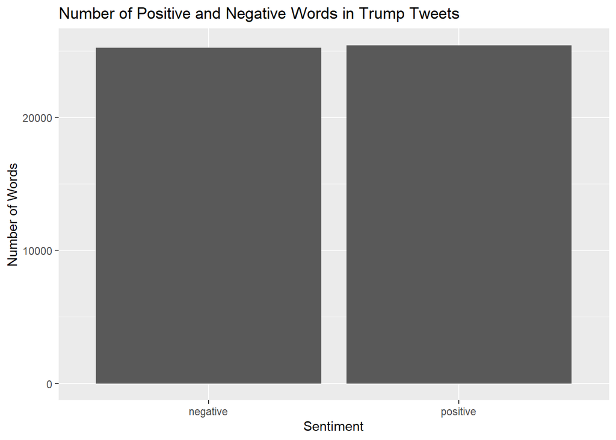

```r
# Visualization of the sentiments
ggplot(trump_main, aes(x = sentiment)) +
  geom_bar() +
  ggtitle("Number of Positive and Negative Words in Trump Tweets") +
  labs(x = "Sentiment", y = "Number of Words")
```

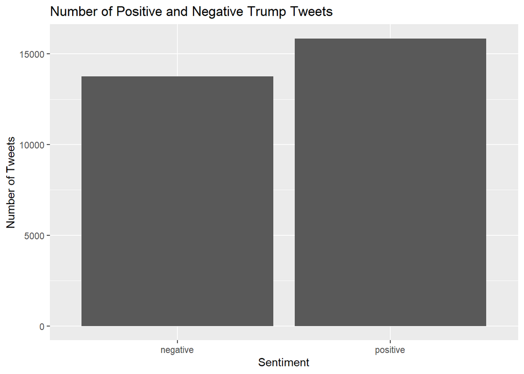

```r
#counts the sentiments of each tweet
trump_main %>%
  group_by(tweet_id) %>%
  count(sentiment) %>%
  ggplot(aes(x = sentiment)) +
  geom_histogram(stat = "count") +
  ggtitle("Number of Positive and Negative Trump Tweets") +
  labs(x = "Sentiment", y = "Number of Tweets")
```

I repeated the same process with the Biden tibble.

```r
# Counts the number of sentiment words
biden_main %>%
  count(sentiment)
```

```
## # A tibble: 2 x 2
##   sentiment      n
##   <chr>      <int>
## 1 negative  330039
## 2 positive  404664
```

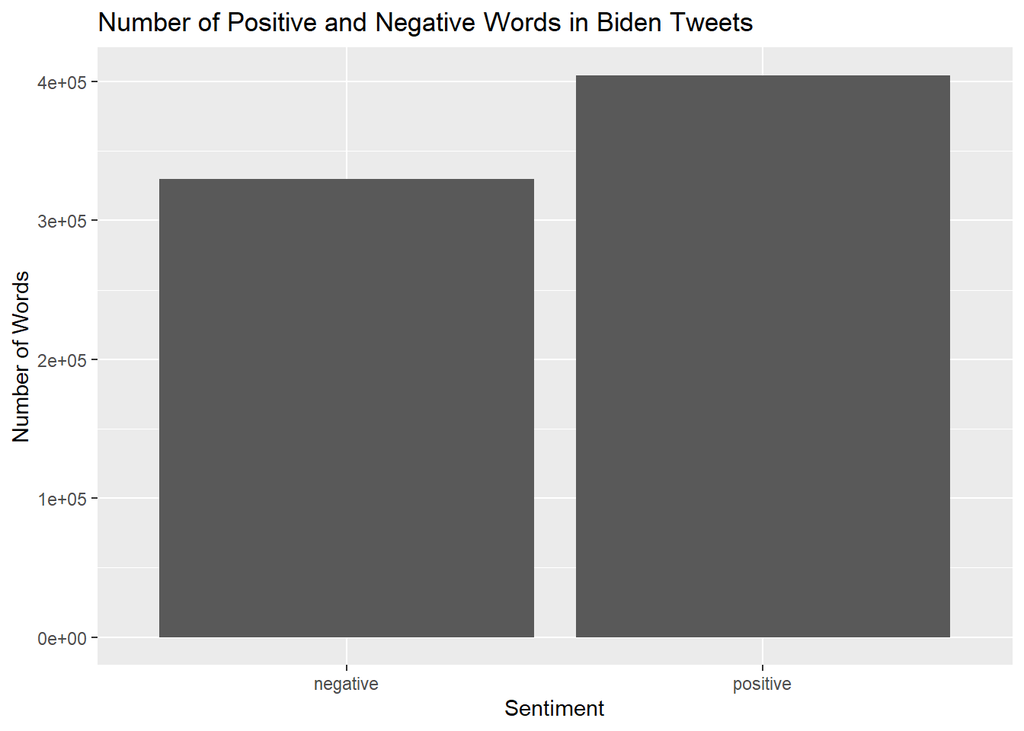

```r
# Visualization of the sentiments
ggplot(biden_main, aes(x = sentiment)) +
  geom_bar() +
  ggtitle("Number of Positive and Negative Words in Biden Tweets") +
  labs(x = "Sentiment", y = "Number of Words")
```

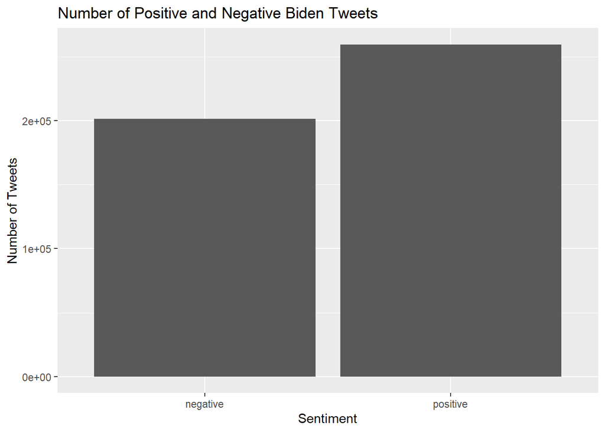

```r
#counts the sentiments of each tweet
biden_main %>%
  group_by(tweet_id) %>%
  count(sentiment) %>%
  ggplot(aes(x = sentiment)) +
  geom_histogram(stat = "count") +
  ggtitle("Number of Positive and Negative Biden Tweets") +
  labs(x = "Sentiment", y = "Number of Tweets")
```

### How did the percentage of positive and negative words each day change over the course of the election month?

I found the percentage of positive and negative words in order to gain a sense of the tone and frequency of the tweets. The percentage of positive and negative words in each tweet shows the frequency of positve and negative words in tweets when graphed over time.

I wanted to find the percentage of negative and positve words in each tweet over the course of election month. However, because that’s a lot of data, the graphs were incredibly messy and did not provide helpful information.

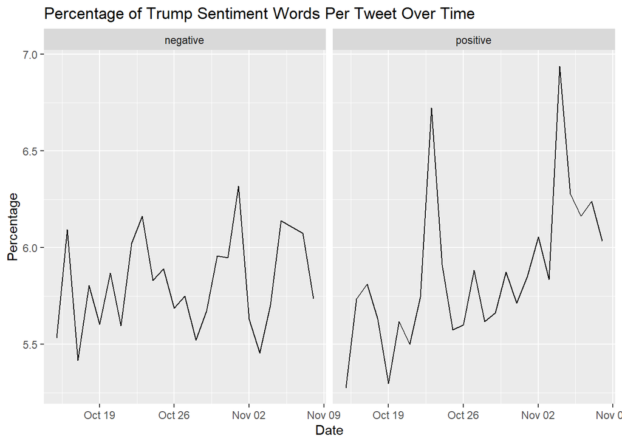

```r
trump_num_words <- hashtag_donaldtrump %>%
  mutate(
    trump_words = str_replace_all(tweet, "[^[A-Za-z,]]", " ") %>%
      str_squish(.) %>%
      str_replace_all(.,",",",") %>%
      str_split(boundary("word")),
    tweet_id = row_number()
  ) %>%
  unnest(trump_words) %>%
  count(tweet_id)

trump_main %>%
  mutate(created_at = ymd_hms(created_at)) %>%
  group_by(created_at, tweet_id) %>%
  count(sentiment) %>%
  inner_join(trump_num_words, by = "tweet_id", "tweet_id") %>%
  mutate(perc = ((n.x / n.y) * 100)) %>%
  group_by(date(created_at), sentiment) %>%
  summarise(perc = mean(perc)) %>%
  ggplot(aes(x = `date(created_at)`, y = perc), color = sentiment) +
  geom_line() +
  facet_wrap(~sentiment) +
  ggtitle("Percentage of Trump Sentiment Words Per Tweet Over Time") +
  labs(x = "Date", y = "Percentage")
```

I repeated the same process with the Biden tibble.

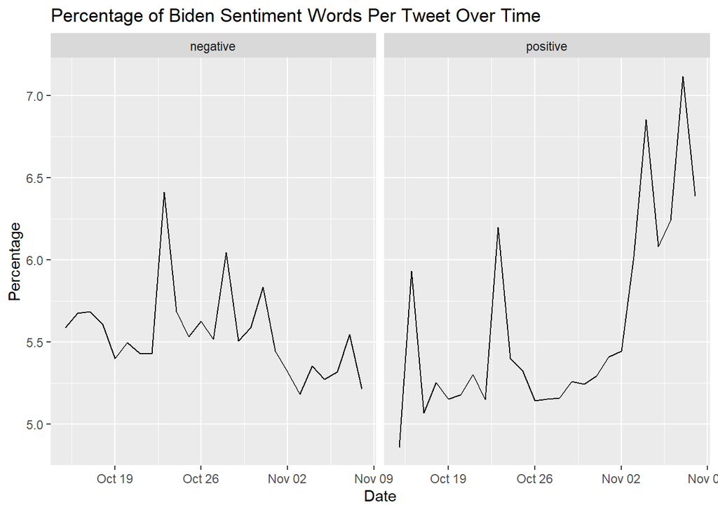

```r
biden_num_words <- hashtag_joebiden %>%
  mutate(
    biden_words = str_replace_all(tweet, "[^[A-Za-z,]]", " ") %>%
      str_squish(.) %>%
      str_replace_all(.,",",",") %>%
      str_split(boundary("word")),
    tweet_id = row_number()
  ) %>%
  unnest(biden_words) %>%
  count(tweet_id)

biden_main %>%
  mutate(created_at = ymd_hms(created_at)) %>%
  group_by(created_at, tweet_id) %>%
  count(sentiment) %>%
  inner_join(biden_num_words, by = "tweet_id", "tweet_id") %>%
  mutate(perc = ((n.x / n.y) * 100)) %>%
  group_by(date(created_at), sentiment) %>%
  summarise(perc = mean(perc)) %>%
  ggplot(aes(x = `date(created_at)`, y = perc), color = sentiment) +
  geom_line() +
  facet_wrap(~sentiment) +
  ggtitle("Percentage of Biden Sentiment Words Per Tweet Over Time") +
  labs(x = "Date", y = "Percentage")
```

### What was the ratio of negative to positive words in tweets?

I counted the number of tweets that have different negative to positive word ratios for both candidates. The ratio shows how many tweets have definitively negative or positive sentiments for each candidate.

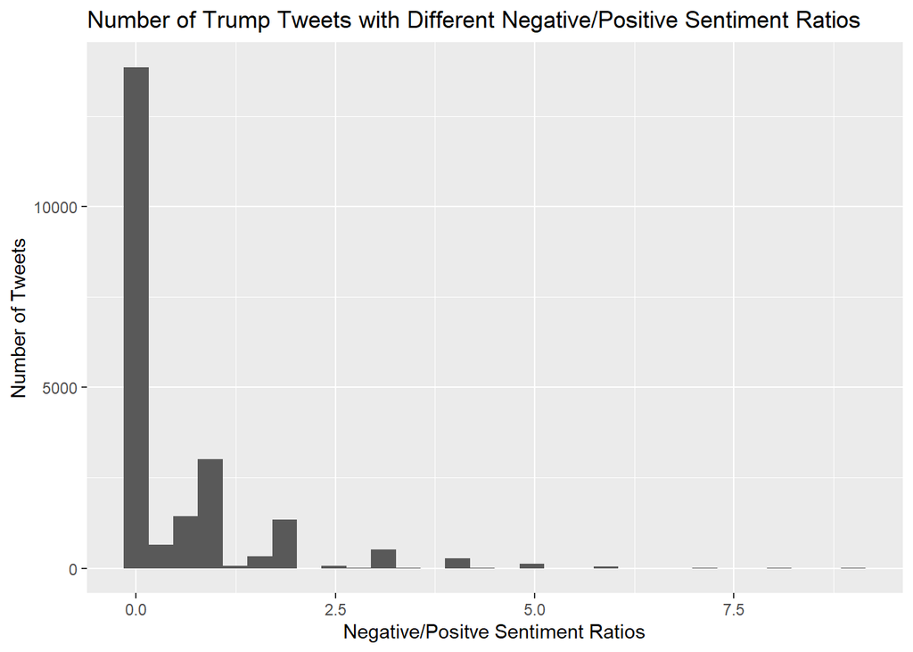

```r
# Calculate ratio of negative to positive words per tweet
# The 0 column includes tweets that only use negative words (no positive words found)

trump_main %>%
  group_by(tweet_id) %>%
  count(sentiment) %>%
  pivot_wider(names_from = sentiment, values_from = n) %>%
  mutate(ratio = negative / positive) %>%
  mutate(negative = replace_na(negative, 0)) %>%
  mutate(positive = replace_na(positive, 0)) %>%
  mutate(ratio = replace_na(ratio, 0)) %>%
  ggplot(aes(x = ratio), stat_bin(drop = FALSE), na.rm = FALSE) +
  geom_histogram() +
  ggtitle("Number of Trump Tweets with Different Negative/Positive Sentiment Ratios") +
  labs(x = "Negative/Positve Sentiment Ratios", y = "Number of Tweets")
```

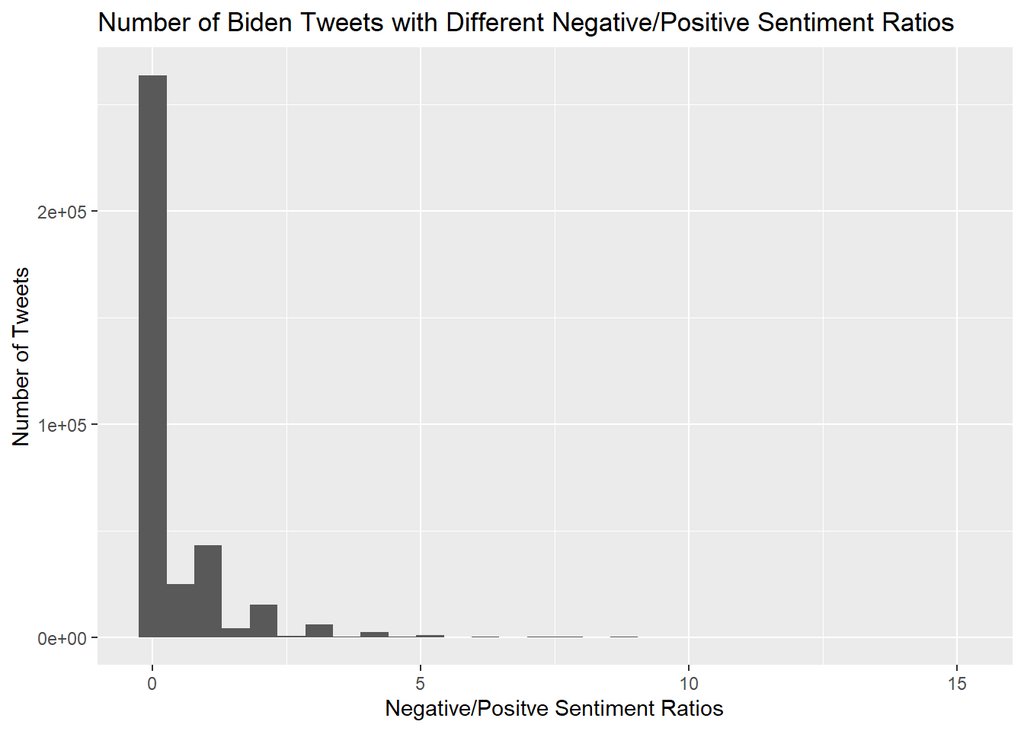

```r
# Find the ratio of negative to positive words and then graph the distribution
biden_main %>%
  group_by(tweet_id) %>%
  count(sentiment) %>%
  pivot_wider(names_from = sentiment, values_from = n) %>%
  mutate(ratio = negative / positive) %>%
  mutate(negative = replace_na(negative, 0)) %>%
  mutate(positive = replace_na(positive, 0)) %>%
  mutate(ratio = replace_na(ratio, 0)) %>%
  ggplot(aes(x = ratio), stat_bin(drop = FALSE), na.rm = FALSE) +
  geom_histogram() +
  ggtitle("Number of Biden Tweets with Different Negative/Positive Sentiment Ratios") +
  labs(x = "Negative/Positve Sentiment Ratios", y = "Number of Tweets")
```

### How do Twitter users interact with tweets with positive or negative tweets through likes and retweets?

Twitter user engagement with tweets of different sentiments indicates how much users approve of the content tweeted. I wanted to look at the number of likes and retweets both to see if tweets with more extreme sentiments elicit a potentially more emotionally-charged reaction and gain more engagement with the tweets. Additionally, tweets that receive more likes and retweets also tend to get more exposure because the likes and retweets boost tweets and expand their networks.

```r
# Counts the number of positive or negative words for the tweets with the most retweets
trump_main %>%
  group_by(tweet_id) %>%
  count(retweet_count, sentiment) %>%
  # I arranged the tibble descending by retweets to see the tweets with the most retweets
  arrange(desc(retweet_count))
```

```
## # A tibble: 29,616 x 4
## # Groups:   tweet_id [21,734]
##    tweet_id retweet_count sentiment     n
##       <int>         <dbl> <chr>     <int>
##  1    25174          3466 positive      1
##  2    27371          2360 negative      2
##  3    32761          2084 negative      3
##  4     3160          1669 negative      1
##  5     3160          1669 positive      2
##  6     1027          1665 positive      1
##  7    25560          1658 negative      3
##  8    25560          1658 positive      3
##  9    23823          1382 negative      1
## 10    23823          1382 positive      1
## # ... with 29,606 more rows
```

I arranged the tibble to count the number of retweets and the number of sentiment words for each of the most retweeted tweets.

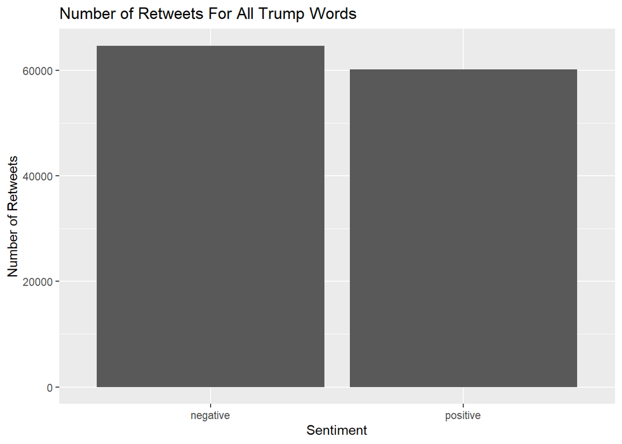

```r
# Graph of the number of retweets with positive or negative words
ggplot(trump_main, aes(x = sentiment, y = retweet_count)) +
  geom_bar(stat = "identity") +
  ggtitle("Number of Retweets For All Trump Words") +
  labs(x = "Sentiment", y = "Number of Retweets")
```

The graph shows that there are more retweets of tweets about Trump with a negative sentiment than a positive sentiment. The more villifying tweets gain more attention, potentially increasing affective polarization among Biden supporters because it increases exposure to tweets that are more negative towards the other side and increases dislike of the other side.

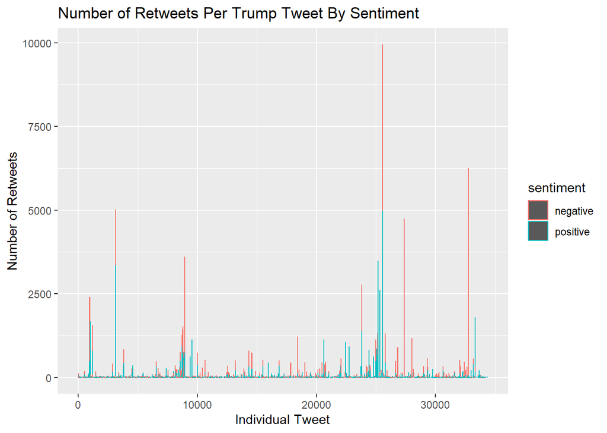

```r
# Graph of the number of retweets each tweet got with the color being the sentiment of the tweet
ggplot(trump_main, aes(x = tweet_id, y = retweet_count, color = sentiment)) +
  geom_bar(stat = "identity") +
  ggtitle("Number of Retweets Per Trump Tweet By Sentiment") +
  labs(x = "Individual Tweet", y = "Number of Retweets")
```

This graph shows the number of retweets each tweet received by the sentiment of each tweet.

Repeat the process with the Biden dataset.

```r
# Counts the number of positive or negative words for the tweets with the most retweets
biden_main %>%
  group_by(tweet_id) %>%
  count(retweet_count, sentiment) %>%
  # I arranged the tibble descending by retweets to see the tweets with the most retweets
  arrange(desc(retweet_count))
```

```
## # A tibble: 461,408 x 4
## # Groups:   tweet_id [360,935]
##    tweet_id retweet_count sentiment     n
##       <int>         <dbl> <chr>     <int>
##  1    10626         63473 negative      1
##  2   164998         18272 positive      2
##  3    20436         17652 positive      6
##  4   298232         14024 positive      2
##  5   278951          7553 positive      4
##  6   196719          7489 negative      7
##  7   196719          7489 positive      3
##  8   570477          6302 negative      1
##  9   570477          6302 positive      2
## 10   281656          6133 negative      7
## # ... with 461,398 more rows
```

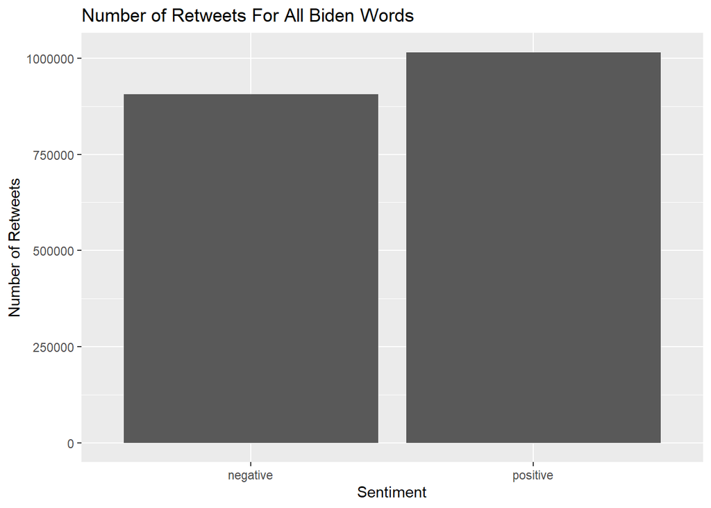

```r
# Graph of the number of retweets with positive or negative words
ggplot(biden_main, aes(x = sentiment, y = retweet_count)) +
  geom_bar(stat = "identity") +
  ggtitle("Number of Retweets For All Biden Words") +
  labs(x = "Sentiment", y = "Number of Retweets")
```

The Biden dataset showed different results from the Trump dataset, with more positive tweets bout Biden receiving retweets than negative tweets.

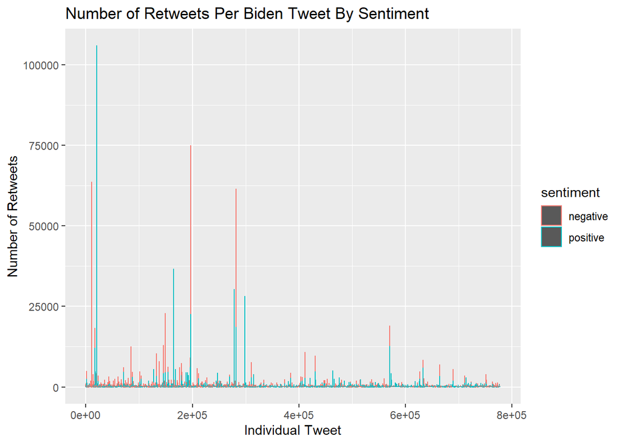

```r
# Graph of the number of retweets each tweet got with the color being the sentiment of the tweet
ggplot(biden_main, aes(x = tweet_id, y = retweet_count, color = sentiment)) +
  geom_bar(stat = "identity") +
  ggtitle("Number of Retweets Per Biden Tweet By Sentiment") +
  labs(x = "Individual Tweet", y = "Number of Retweets")
```

This bar graph showed fewer large spikes than the Trump dataset, but the biggest spike from a particular tweet having more retweets has a positive sentiment, whereas the majority of the Trump spikes were negative. The culmination of the more positive Biden tweets and more negative Biden tweets would indicate that more liberal Twitter users might have a greater sense of affective polarization with a greater sense of “team spirit” for Biden and hatred for Trump.

I repeated the processes again with the number of likes and found similar patterns as the retweet counts, starting with the Trump dataset.

```r
# Counts the number of positive or negative words for the tweets with the most likes
trump_main %>%
  group_by(tweet_id) %>%
  count(likes, sentiment) %>%
  arrange(desc(likes))
```

```
## # A tibble: 29,616 x 4
## # Groups:   tweet_id [21,734]
##    tweet_id likes sentiment     n
##       <int> <dbl> <chr>     <int>
##  1    25174 11018 positive      1
##  2    32761 10839 negative      3
##  3    25560 10238 negative      3
##  4    25560 10238 positive      3
##  5    27379 10047 negative      1
##  6    24985 10010 negative      1
##  7    25324  9920 positive      2
##  8    22433  9239 positive      1
##  9    27371  7888 negative      2
## 10    23823  7388 negative      1
## # ... with 29,606 more rows
```

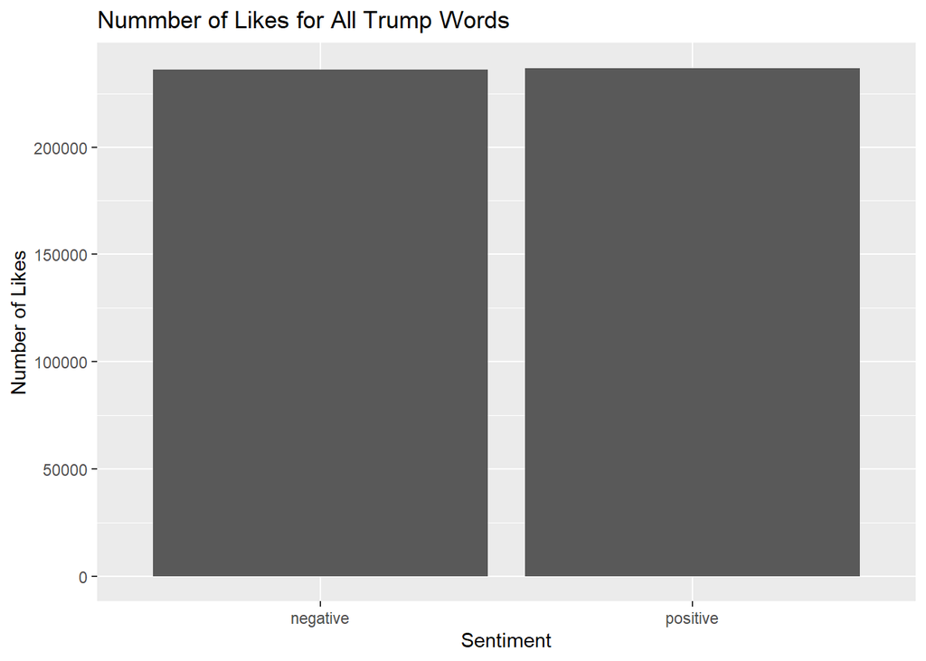

```r
# Graph of the number of likes of tweets with positive or negative words
ggplot(trump_main, aes(x = sentiment, y = likes)) +
  geom_bar(stat = "identity") +
  ggtitle("Nummber of Likes for All Trump Words") +
  labs(x = "Sentiment", y = "Number of Likes")
```

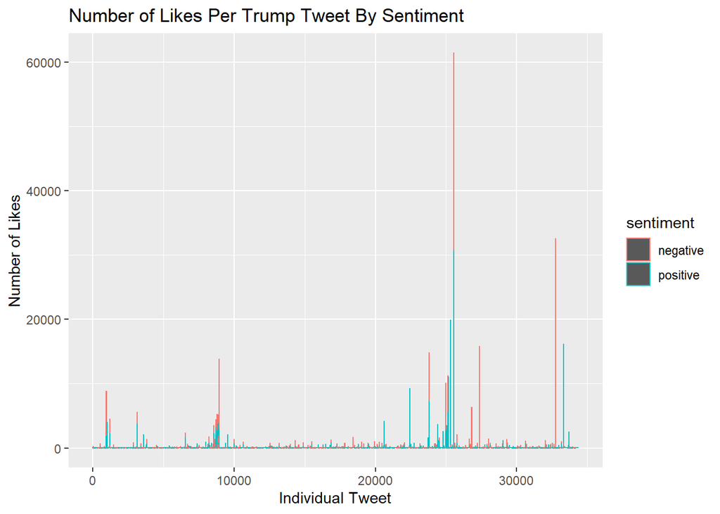

```r
# Graph of the number of likes each tweet got with the color being the sentiment of the tweet
ggplot(trump_main, aes(x = tweet_id, y = likes, color = sentiment)) +
  geom_bar(stat = "identity") +
  ggtitle("Number of Likes Per Trump Tweet By Sentiment") +
  labs(x = "Individual Tweet", y = "Number of Likes")
```

The spikes where there are tweets with a lot of likes had more negative sentiments, but there were also some well-liked tweets with a positive sentiment.

I repeated the process again with the Biden dataset.

```r
# Counts the number of positive or negative words for the tweets with the most likes
biden_main %>%
  group_by(tweet_id) %>%
  count(likes, sentiment) %>%
  arrange(desc(likes))
```

```
## # A tibble: 461,408 x 4
## # Groups:   tweet_id [360,935]
##    tweet_id  likes sentiment     n
##       <int>  <dbl> <chr>     <int>
##  1    20436 165702 positive      6
##  2    10626 143454 negative      1
##  3   298232 126772 positive      2
##  4   278951  80670 positive      4
##  5   196719  59403 negative      7
##  6   196719  59403 positive      3
##  7   713716  59345 positive      1
##  8   164998  46313 positive      2
##  9   281656  45540 negative      7
## 10   281656  45540 positive      3
## # ... with 461,398 more rows
```

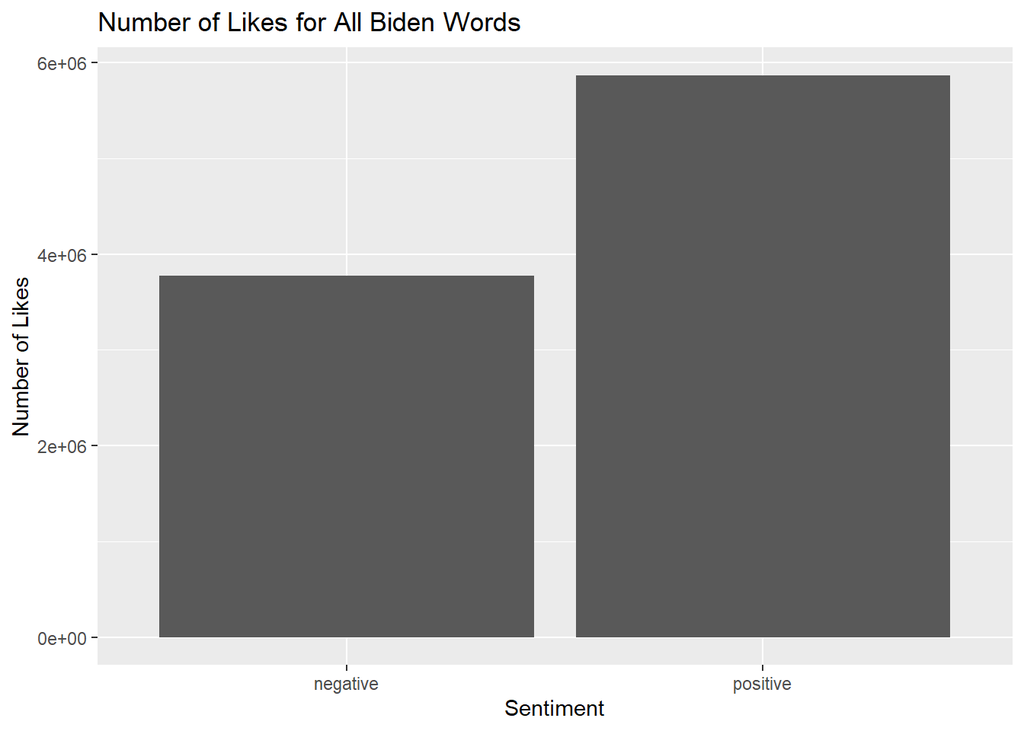

```r
# Graph of the number of likes of tweets with positive or negative words
ggplot(biden_main, aes(x = sentiment, y = likes)) +
  geom_bar(stat = "identity") +
  ggtitle("Number of Likes for All Biden Words") +
  labs(x = "Sentiment", y = "Number of Likes")
```

There were significantly more positive Biden tweets that received likes than negative tweets.

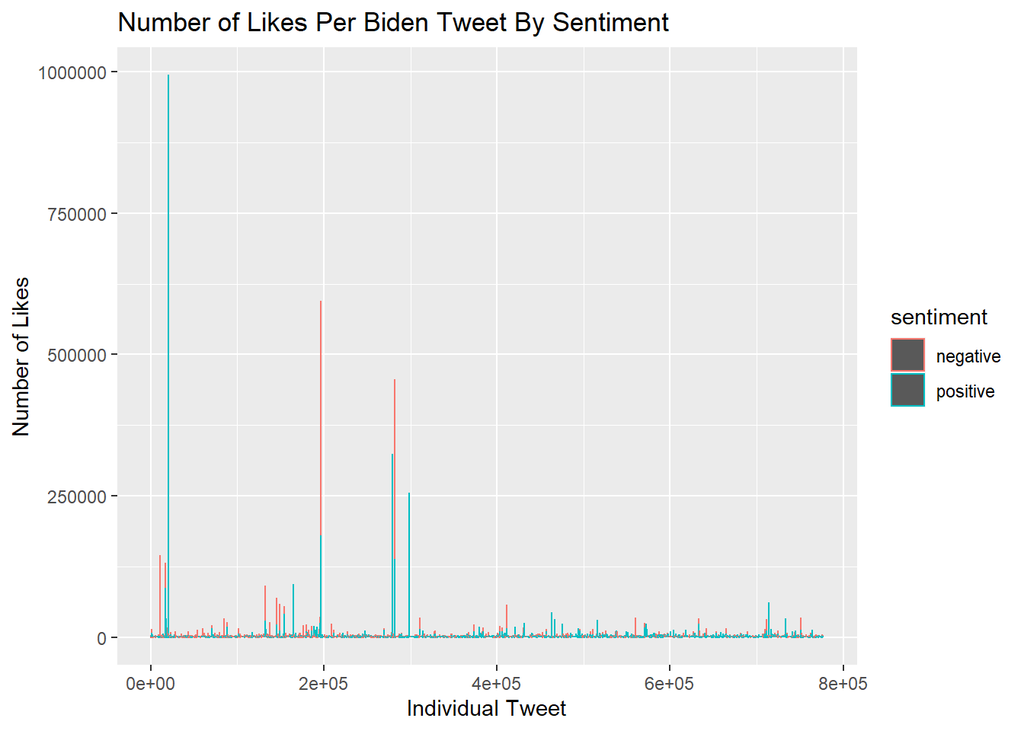

```r
# Graph of the number of likes each tweet got with the color being the sentiment of the tweet
ggplot(biden_main, aes(x = tweet_id, y = likes, color = sentiment)) +
  geom_bar(stat = "identity") +
  ggtitle("Number of Likes Per Biden Tweet By Sentiment") +
  labs(x = "Individual Tweet", y = "Number of Likes")
```

The majority of the most liked tweets had a positive sentiment, but there were a few more well-liked negative tweets about Biden than from the retweet graph.

Based on the proportions of negative an positive liked or retweeted tweets, it appears that Biden supporters both tweeted positive things abut Biden and negative things about Trump consistently (perhaps with more negative Trump tweets gaining traction). Trump supporters tended to tweet positive things about Trump. Although they also tweeted negative things about Biden, Trump supporters seemed to engage more with tweets that were rallying around Trump than speaking negatively of Biden. While supporters of both candidates interacted with both negative and positive tweets, if number of likes and retweets indicates how much exposure the tweets received, Biden supporters may experience more affective polarization than Trump supporters because they can use the anger they’re exposed to as a way to be against Trump. If those negative Trump tweets also end up in the networks of Trump supporters, they might experience an increase in affective polarization because they’re seeeing negative things about their own candidate, which might elicit an angry reaction that would increase negative feelings about Biden supporters.

# Afinn Data

### What is the typical extremity of the tweet sentiments?

I used the Afinn sentiment lexicon, which gives an integer value from -5 to 5 of the negative or positive sentiment of each words. The sentiment value shows how loaded the sentiments are and gives more information about the tweets’ tone.

```r
### afinn data

trump_main <- hashtag_donaldtrump %>%
  mutate(
    trump_words = str_replace_all(tweet, "[^[A-Za-z,]]", " ") %>%
      str_squish(.) %>%
      str_replace_all(.,",",",") %>%
      str_split(boundary("word")),
    tweet_id = row_number()
  ) %>%
  unnest(trump_words)

afinn_sent <- get_sentiments("afinn")

trump_main <- trump_main %>%
  inner_join(afinn_sent, by = c("trump_words" = "word"))
```

I counted the number of words with each sentiment value. The biggest integer level for both positive and negative sentiments was integer level 2, so primarily the sentiment words were a bit negative or positive, but not very extreme.

```r
# Counts the number of words with each sentiment value
trump_main %>%
  count(value)
```

```
## # A tibble: 10 x 2
##    value     n
##    <dbl> <int>
##  1    -5    83
##  2    -4  1399
##  3    -3  6299
##  4    -2  8955
##  5    -1  5768
##  6     1  5891
##  7     2  9004
##  8     3  3458
##  9     4  2108
## 10     5    22
```

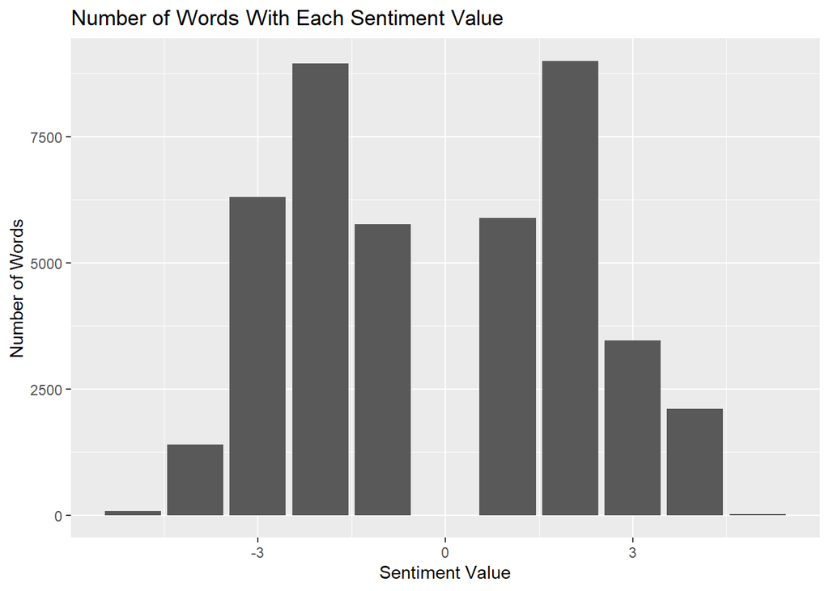

```r
# Graph the number of words with each sentiment value
trump_main %>%
  count(value) %>%
  ggplot(aes(x = value, y = n)) +
  geom_bar(stat = "identity") +
  ggtitle("Number of Words With Each Sentiment Value") +
  labs(x = "Sentiment Value", y = "Number of Words")
```

The grah visualizes the distribution of words with each sentiment value. For both positive and negative words, the value peaks at 2 and decreases as the words get more extreme.

```r
# Graph the number of words with each value per tweet
trump_main %>%
  group_by(tweet_id) %>%
  count(trump_words, value)
```

```
## # A tibble: 41,044 x 4
## # Groups:   tweet_id [19,239]
##    tweet_id trump_words value     n
##       <int> <chr>       <dbl> <int>
##  1        1 attacking      -1     1
##  2        5 lost           -3     1
##  3        5 wrong          -2     1
##  4        7 crime          -3     1
##  5        7 criminal       -3     1
##  6        7 justice         2     1
##  7        7 outrage        -3     1
##  8        7 travesty       -2     1
##  9        9 approved        2     1
## 10        9 cheat          -3     1
## # ... with 41,034 more rows
```

I counted the number of words per tweet with a positive or negative sentiment, and this table also gives examples of words of any sentiment value.

```r
# Finding the descriptive statistics of the sentiment values for all the words
trump_main %>%
  summarise(mean = mean(value), median = median(value), sd = sd(value), n = n())
```

```
## # A tibble: 1 x 4
##     mean median    sd     n
##    <dbl>  <dbl> <dbl> <int>
## 1 -0.134     -1  2.31 42987
```

On average, the sentiment of the words used were barely negative and would be rounded to zero. The sentiment value of all tweets about Trump and Biden leveled out to about a net neutral, but the median value was -1, indicating a more definitive negative shift in all words tweeted about Donald Trump.

I repeated the process again with Biden.

```r
biden_main <- hashtag_joebiden %>%
  mutate(
    biden_words = str_replace_all(tweet, "[^[A-Za-z,]]", " ") %>%
      str_squish(.) %>%
      str_replace_all(.,",",",") %>%
      str_split(boundary("word")),
    tweet_id = row_number()
  ) %>%
  unnest(biden_words)

afinn_sent <- get_sentiments("afinn")

biden_main <- biden_main %>%
  inner_join(afinn_sent, by = c("biden_words" = "word"))
```

```r
# Counts the number of words with each sentiment value
biden_main %>%
  count(value)
```

```
## # A tibble: 10 x 2
##    value      n
##    <dbl>  <int>
##  1    -5   1137
##  2    -4  18776
##  3    -3  85942
##  4    -2 109506
##  5    -1  83788
##  6     1  94199
##  7     2 154502
##  8     3  74629
##  9     4  52793
## 10     5    492
```

Once again, the positive and negative sentiment words were mostly at a value of 2 or -2, showing that were were a bit positive or negative, and decreasing as the words got more extreme in both directions.

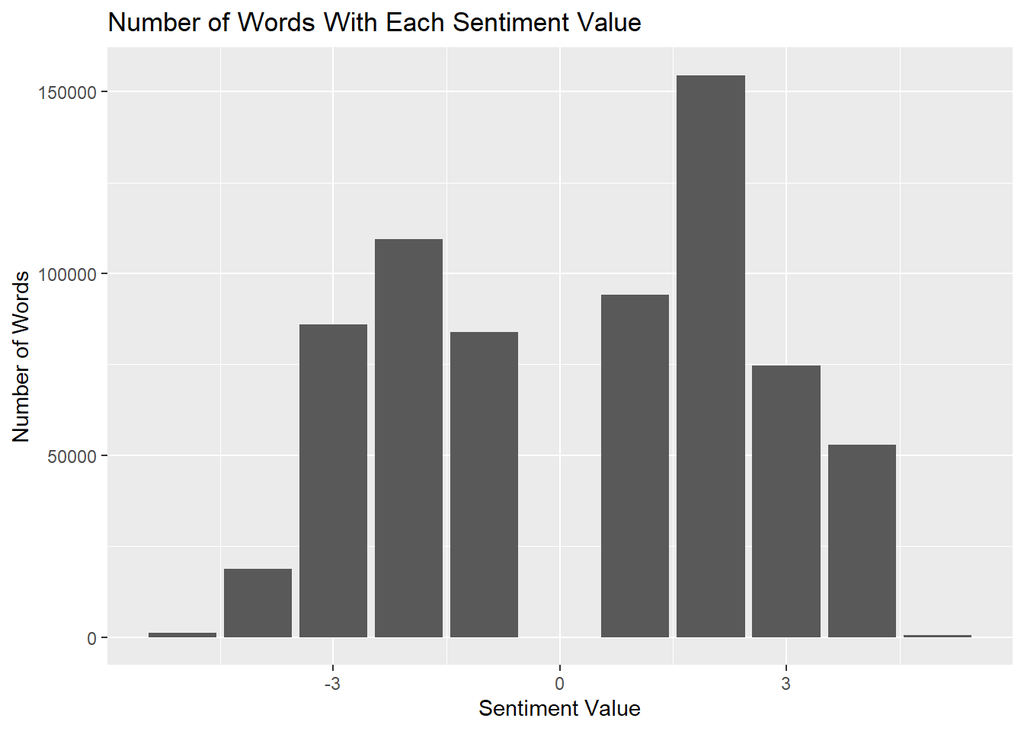

```r
# Graph the number of words with each sentiment value
biden_main %>%
  count(value) %>%
  ggplot(aes(x = value, y = n)) +
  geom_bar(stat = "identity") +
  ggtitle("Number of Words With Each Sentiment Value") +
  labs(x = "Sentiment Value", y = "Number of Words")
```

The graph provides a visualization of the count distribution. There were more somewhat positive words tweeted about Biden than negative words, but the pattern is the same on both ends.

```r
# Graph the number of words with each value per tweet
biden_main %>%
  group_by(tweet_id) %>%
  count(biden_words, value)
```

```
## # A tibble: 644,711 x 4
## # Groups:   tweet_id [338,643]
##    tweet_id biden_words value     n
##       <int> <chr>       <dbl> <int>
##  1        7 favor           2     1
##  2        7 fine            2     1
##  3        7 sick           -2     1
##  4       10 suspend        -1     1
##  5       11 chaos          -2     1
##  6       11 excitement      3     1
##  7       11 popular         3     1
##  8       11 win             4     1
##  9       15 riots          -2     1
## 10       15 worse          -3     1
## # ... with 644,701 more rows
```

The table gives the number of positive and negative words per tweet, along with the sentiment values, and shows what the words used are.

```r
# Finding the descriptive statistics of the sentiment values for all the words
biden_main %>%
  summarise(mean = mean(value), median = median(value), sd = sd(value), n = n())
```

```
## # A tibble: 1 x 4
##    mean median    sd      n
##   <dbl>  <dbl> <dbl>  <int>
## 1 0.295      1  2.37 675764
```

For tweets about Biden, the mean was also close to zero, but more positive. The median also had an absolute value of 1, but for the tweets about Biden they shifted positive rather than negative.

### What is the average sentimental tweets over time?

I graphed the average sentiment value of the tweets created each day in the data’s timeframe because I wanted to see how the sentiment value of tweets overall changed with closer proximity to the election. For both candidates, once Election Day hit they received a spike in average sentiment value going more positive than before. However, tweets about Trump were on average more negative and then did not stay as positive after Election Day as tweets about Biden.

Trump sentiment value over time

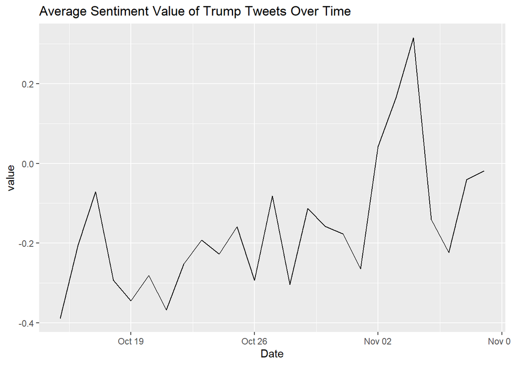

```r
# Graphs the average sentiment of each tweet over time
trump_main %>%
  mutate(created_at = ymd_hms(created_at)) %>%
  group_by(date(created_at)) %>%
  summarise(value = mean(value)) %>%
  ggplot(aes(x = `date(created_at)`, y = value)) +
  geom_line() +
  ggtitle("Average Sentiment Value of Trump Tweets Over Time") +
  labs(x = "Date", "Sentiment Value")
```

Biden sentiment value over time

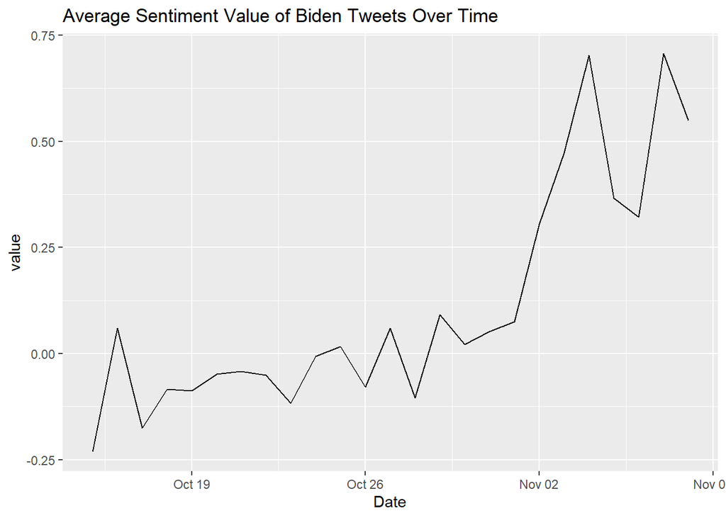

```r
# Graph average sentiment value over time
biden_main %>%
  mutate(created_at = ymd_hms(created_at)) %>%
  group_by(date(created_at)) %>%
  summarise(value = mean(value)) %>%
  ggplot(aes(x = `date(created_at)`, y = value)) +
  geom_line() +
  ggtitle("Average Sentiment Value of Biden Tweets Over Time") +
  labs(x = "Date", "Sentiment Value")
```

### Is there a relationship between the average sentiment value of tweets and the number of likes or retweets they receive?

The regression summaries show the relationships between the average sentiment value of tweets and either the number of likes or number of retweets received, controlling for the users’ follower counts or number of likes or retweets depending on which was the dependent variable in the regression formula. I controlled for follower counts because it affects each users’ inherent network size and the expected number of people to view a tweet. I also controlled for likes and retweets because both increase the engagement of a tweet, so a tweet with more likes will receive more views, as will a tweet with more retweets. Increased engagement could lead to increased interaction with tweets.

Trump regressions

```r
summary(
  trump_main %>%
    group_by(tweet_id) %>%
    mutate(value_group = mean(value)) %>%
    ungroup() %>%
    distinct(tweet_id, .keep_all = T) %>%
    lm(formula = likes ~ value_group + user_followers_count + retweet_count))
```

```
##
## Call:
## lm(formula = likes ~ value_group + user_followers_count + retweet_count,
##     data = .)
##
## Residuals:
##     Min      1Q  Median      3Q     Max
## -4340.1     1.9     3.5     4.7  5459.5
##
## Coefficients:
##                        Estimate Std. Error t value Pr(>|t|)
## (Intercept)          -4.148e+00  7.984e-01  -5.195 2.07e-07 ***
## value_group           4.741e-01  4.070e-01   1.165    0.244
## user_followers_count  5.630e-04  1.437e-05  39.173  < 2e-16 ***
## retweet_count         3.672e+00  1.672e-02 219.592  < 2e-16 ***
## ---
## Signif. codes:  0 '***' 0.001 '**' 0.01 '*' 0.05 '.' 0.1 ' ' 1
##
## Residual standard error: 109.7 on 19235 degrees of freedom
## Multiple R-squared:  0.7829, Adjusted R-squared:  0.7829
## F-statistic: 2.312e+04 on 3 and 19235 DF,  p-value: < 2.2e-16
```

```r
summary(trump_main %>%
  group_by(tweet_id) %>%
  mutate(value_group = mean(value)) %>%
    ungroup() %>%
    distinct(tweet_id, .keep_all = T) %>%
  lm(formula = retweet_count ~ value_group + user_followers_count + likes))
```

```
##
## Call:
## lm(formula = retweet_count ~ value_group + user_followers_count +
##     likes, data = .)
##
## Residuals:
##     Min      1Q  Median      3Q     Max
## -881.96   -0.99   -0.79   -0.57 1440.19
##
## Coefficients:
##                        Estimate Std. Error t value Pr(>|t|)
## (Intercept)           7.858e-01  1.839e-01   4.274 1.93e-05 ***
## value_group          -1.017e-01  9.370e-02  -1.085   0.2778
## user_followers_count -6.201e-06  3.438e-06  -1.804   0.0713 .
## likes                 1.947e-01  8.864e-04 219.592  < 2e-16 ***
## ---
## Signif. codes:  0 '***' 0.001 '**' 0.01 '*' 0.05 '.' 0.1 ' ' 1
##
## Residual standard error: 25.26 on 19235 degrees of freedom
## Multiple R-squared:  0.7656, Adjusted R-squared:  0.7656
## F-statistic: 2.094e+04 on 3 and 19235 DF,  p-value: < 2.2e-16
```

Biden regressions

```r
summary(
  biden_main %>%
    group_by(tweet_id) %>%
    mutate(value_group = mean(value)) %>%
    ungroup() %>%
    distinct(tweet_id, .keep_all = T) %>%
    lm(formula = likes ~ value_group + as.numeric(user_followers_count) + retweet_count))
```

```
##
## Call:
## lm(formula = likes ~ value_group + as.numeric(user_followers_count) +
##     retweet_count, data = .)
##
## Residuals:
##    Min     1Q Median     3Q    Max
## -51995      3      3      4 110816
##
## Coefficients:
##                                    Estimate Std. Error t value Pr(>|t|)
## (Intercept)                      -3.579e+00  5.050e-01  -7.086 1.38e-12 ***
## value_group                       1.420e-01  2.375e-01   0.598     0.55
## as.numeric(user_followers_count)  4.163e-04  1.671e-06 249.185  < 2e-16 ***
## retweet_count                     3.062e+00  3.926e-03 779.799  < 2e-16 ***
## ---
## Signif. codes:  0 '***' 0.001 '**' 0.01 '*' 0.05 '.' 0.1 ' ' 1
##
## Residual standard error: 288.9 on 338578 degrees of freedom
##   (61 observations deleted due to missingness)
## Multiple R-squared:  0.6936, Adjusted R-squared:  0.6935
## F-statistic: 2.554e+05 on 3 and 338578 DF,  p-value: < 2.2e-16
```

```r
summary(
  biden_main %>%
    group_by(tweet_id) %>%
    mutate(value_group = mean(value)) %>%
    ungroup() %>%
    distinct(tweet_id, .keep_all = T) %>%
    lm(formula = retweet_count ~ value_group + as.numeric(user_followers_count) + likes))
```

```
##
## Call:
## lm(formula = retweet_count ~ value_group + as.numeric(user_followers_count) +
##     likes, data = .)
##
## Residuals:
##    Min     1Q Median     3Q    Max
## -16992     -1     -1     -1  33535
##
## Coefficients:
##                                    Estimate Std. Error  t value Pr(>|t|)
## (Intercept)                       1.198e+00  1.322e-01    9.061   <2e-16 ***
## value_group                      -1.074e-01  6.218e-02   -1.727   0.0842 .
## as.numeric(user_followers_count) -5.965e-05  4.646e-07 -128.401   <2e-16 ***
## likes                             2.098e-01  2.690e-04  779.799   <2e-16 ***
## ---
## Signif. codes:  0 '***' 0.001 '**' 0.01 '*' 0.05 '.' 0.1 ' ' 1
##
## Residual standard error: 75.63 on 338578 degrees of freedom
##   (61 observations deleted due to missingness)
## Multiple R-squared:  0.6542, Adjusted R-squared:  0.6542
## F-statistic: 2.135e+05 on 3 and 338578 DF,  p-value: < 2.2e-16
```